# Perform concordance network-based clustering using PRONA

This vignette gives an overview of how to perform second-order, concordance network-based unsupervised clustering to identify communities of patients with unique symptom network patterns. For more information on this clustering method and examples of its applications, please see [Henry et al., Plos One, 2018](https://doi.org/10.1371/journal.pone.0191981), [Bergsneider et al., Neuro-Oncology Advances, 2022](https://doi.org/10.1093/noajnl/vdac188), and [Bergsneider et al., Cancer Medicine, 2024](https://doi.org/10.1002/cam4.70278).

### 1. Load PRONA, download data, and construct a GGM

For this example, we will use the data from the introduction vignette to construct a GGM. Please refer to the introduction vignette for more details on where this data is from and how the network is constructed.

```r
library(PRONA)
reduced_df <- read.csv('../../PRONA_additional_files/test_scripts/output/reduced_data.csv', stringsAsFactors = FALSE)
ptsd_network <- construct_ggm(reduced_df, normal = FALSE)
```

```
## Conducting nonparanormal (npn) transformation via skeptic....done.
```

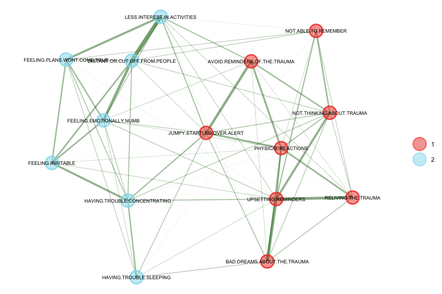

```r
plot_ggm(ptsd_network, label.size = 2.5)
```

### 2. Get communities of patients with unique symptom severity/frequency patterns

To run second-order unsupervised clustering, we use the get_communities function, which has 6 parameters:

- data: Dataframe of symptom severities (formatted as required by PRONA)
- nrows: Number of rows in the dataframe (Defaults to the number of rows in data, you should not change this parameter)
- ncols: Number of columns in the dataframe (Defaults to the number of columns in data, you should not change this parameter)
- detectAlgo: The community detection algorithm to use. Options include FG (fast greedy), IM (infomap), LP (label propagation), LE (leading eigen), LV (louvain), or WT (walktrap). (Default: WT)
- simil_measure: The similarity measure to use, either ‘Euclidean’ or ‘ARI’ (Adjusted Rand Index) (Default: ARI)
- simplify_graphs: Boolean that indicates whether to simplify the graph by removing multi-edges and loops (Default: TRUE)

It returns a new dataframe that is a copy of the original symptom severities dataframe, but with a new column representing which community each patient belongs to.

```r
community_df <- get_communities(reduced_df)
```

Lets see how many patients are in each community

```r
table(community_df$community)
```

```
##
##   1   2   3
## 136 218   5
```

Next, lets plot a heatmap of symptom severities for each community using the plot_community_heatmap function, which has four parameters:

- df: The output of the get_communities function
- cluster_rows: Boolean representing whether or not to cluster the rows (symptoms) via heirarchical clustering (Default: TRUE)
- network: A network object output by construct_ggm. If a network is passed into this function, the heatmap will automatically order rows (symptoms) by the symptom clusters identified in the network. This overrides the cluster_rows parameter. (Default: NULL)
- row_label_size: The font size of the row labels (Default: 10)

Here, “PC” stands for “Patient Community”:

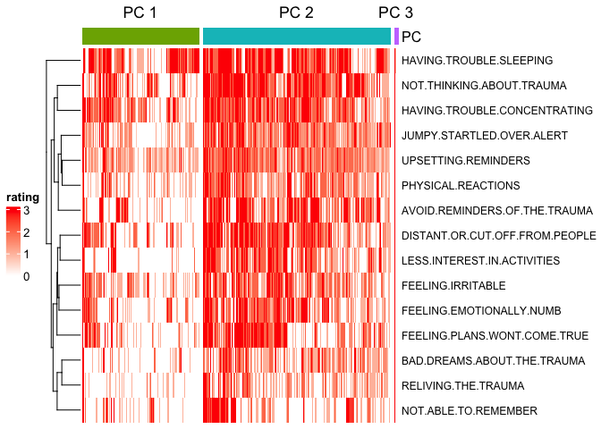

```r
plot_community_heatmap(community_df, row_label_size = 9)
```

Here’s how to order rows based on the symptom clusters identified during network construction:

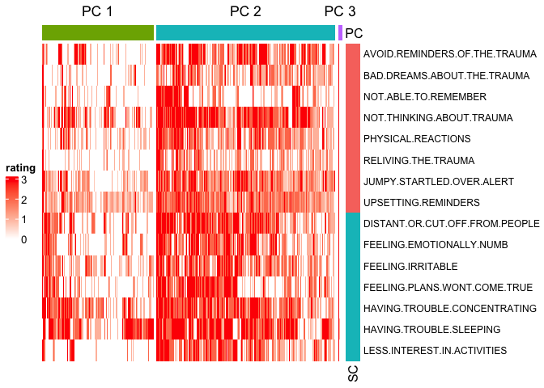

```r
plot_community_heatmap(community_df, network = ptsd_network, row_label_size = 9)
```

We can also visualize the symptom severities of each community using line plots. The community_line_plot function has two parameters:

- data: output of get_communities
- communities: ector specifying which communities to plot. If you include 0 in the vector, it will plot the severity for all patients combined. (Default: c(0))

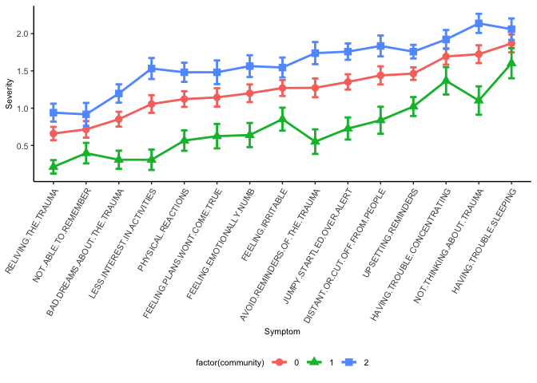

```r
community_line_plot(community_df, c(0,1,2))
```

We can also get a summary of each symptom in each community using the get_community_summary function, which returns a dataframe with the mean, median, upper bound, and lower bound of each symptom in each community.

```r
get_community_summary(community_df)
```

```
## # A tibble: 45 × 6
## # Groups:   community [3]
##    community variable                        mean median upper lower
##        <dbl> <fct>                          <dbl>  <dbl> <dbl> <dbl>
##  1         1 AVOID.REMINDERS.OF.THE.TRAUMA  0.551      0 0.716 0.387
##  2         1 BAD.DREAMS.ABOUT.THE.TRAUMA    0.309      0 0.431 0.187
##  3         1 DISTANT.OR.CUT.OFF.FROM.PEOPLE 0.838      0 1.02  0.657
##  4         1 FEELING.EMOTIONALLY.NUMB       0.640      0 0.802 0.478
##  5         1 FEELING.IRRITABLE              0.853      1 1.01  0.699
##  6         1 FEELING.PLANS.WONT.COME.TRUE   0.625      0 0.789 0.461
##  7         1 HAVING.TROUBLE.CONCENTRATING   1.37       1 1.55  1.18
##  8         1 HAVING.TROUBLE.SLEEPING        1.60       2 1.80  1.40
##  9         1 LESS.INTEREST.IN.ACTIVITIES    0.309      0 0.445 0.172
## 10         1 NOT.ABLE.TO.REMEMBER           0.397      0 0.535 0.259
## # ℹ 35 more rows
```

### 3. Construct networks for individual communities

We can construct GGM networks and conduct statistical assessment for individual communities using the same pipeline as described in the introduction and statistical assessment vignettes.

```r
# Get symptom data for individual communities
library(dplyr)
comm1_df <- community_df[community_df$community==1,] %>% select(-community)
comm2_df <- community_df[community_df$community==2,] %>% select(-community)
```

```r
comm1_ega <- construct_ggm(comm1_df, normal = FALSE)
```

```
## Conducting nonparanormal (npn) transformation via skeptic....done.
```

```r
summary(comm1_ega)
```

```
## Model: GLASSO (EBIC with gamma = 0)
## Correlations: auto
## Lambda: 0.301079593387959 (n = 100, ratio = 0.1)
##
## Number of nodes: 15
## Number of edges: 4
## Edge density: 0.038
##
## Non-zero edge weights:
##      M    SD   Min   Max
##  0.087 0.063 0.038 0.178
##
## ----
##
## Algorithm:  Walktrap
##
## Number of communities:  2
##
##  AVOID.REMINDERS.OF.THE.TRAUMA    BAD.DREAMS.ABOUT.THE.TRAUMA
##                             NA                             NA
## DISTANT.OR.CUT.OFF.FROM.PEOPLE       FEELING.EMOTIONALLY.NUMB
##                              1                              1
##              FEELING.IRRITABLE   FEELING.PLANS.WONT.COME.TRUE
##                              1                             NA
##   HAVING.TROUBLE.CONCENTRATING        HAVING.TROUBLE.SLEEPING
##                             NA                             NA
##    LESS.INTEREST.IN.ACTIVITIES           NOT.ABLE.TO.REMEMBER
##                              1                              2
##      NOT.THINKING.ABOUT.TRAUMA             PHYSICAL.REACTIONS
##                             NA                             NA
##            RELIVING.THE.TRAUMA      JUMPY.STARTLED.OVER.ALERT
##                             NA                             NA
##            UPSETTING.REMINDERS
##                              2
##
## ----
##
## Unidimensional Method: Louvain
## Unidimensional: No
##
## ----
##
## TEFI: -2.513
```

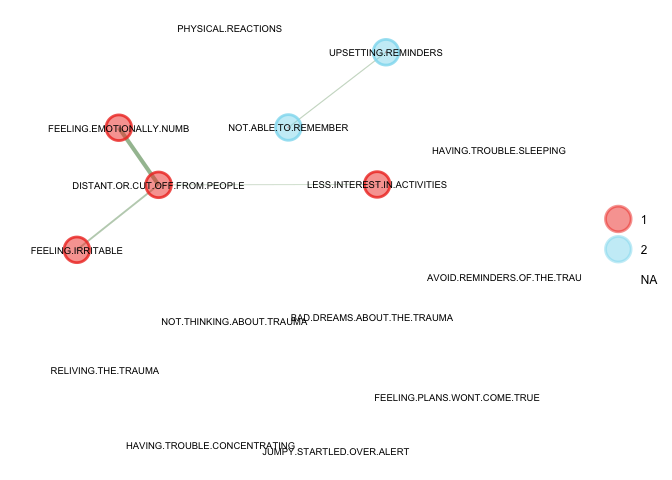

```r
plot_ggm(comm1_ega, label.size = 2.5)
```

```r
comm2_ega <- construct_ggm(comm2_df, normal = FALSE)
```

```
## Conducting nonparanormal (npn) transformation via skeptic....done.
```

```r
summary(comm2_ega)
```

```
## Model: GLASSO (EBIC with gamma = 0.25)
## Correlations: auto
## Lambda: 0.129502975706062 (n = 100, ratio = 0.1)
##
## Number of nodes: 15
## Number of edges: 47
## Edge density: 0.448
##
## Non-zero edge weights:
##      M    SD   Min   Max
##  0.081 0.068 0.001 0.343
##
## ----
##
## Algorithm:  Walktrap
##
## Number of communities:  2
##
##  AVOID.REMINDERS.OF.THE.TRAUMA    BAD.DREAMS.ABOUT.THE.TRAUMA
##                              1                              1
## DISTANT.OR.CUT.OFF.FROM.PEOPLE       FEELING.EMOTIONALLY.NUMB
##                              2                              2
##              FEELING.IRRITABLE   FEELING.PLANS.WONT.COME.TRUE
##                              2                              2
##   HAVING.TROUBLE.CONCENTRATING        HAVING.TROUBLE.SLEEPING
##                              2                              2
##    LESS.INTEREST.IN.ACTIVITIES           NOT.ABLE.TO.REMEMBER
##                              2                              2
##      NOT.THINKING.ABOUT.TRAUMA             PHYSICAL.REACTIONS
##                              1                              1
##            RELIVING.THE.TRAUMA      JUMPY.STARTLED.OVER.ALERT
##                              1                              1
##            UPSETTING.REMINDERS
##                              1
##
## ----
##
## Unidimensional Method: Louvain
## Unidimensional: No
##
## ----
##
## TEFI: -7.476
```

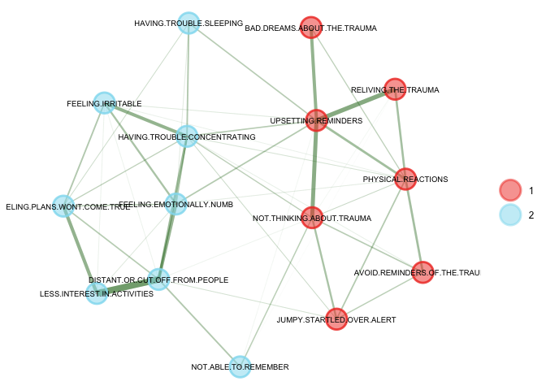

```r
plot_ggm(comm2_ega, label.size = 2.5)
```

Because of its relatively low number of patients and low overall symptom severity, the network for PC1 is sparse.

### 4. Perform Network Comparison Test (NCT)

We can statistically assess the differences between the two networks using the Network Comparison Test. For details on how the Network Comparison Test works, please see [Borkulo et al., Psychol Methods, 2022](https://pubmed.ncbi.nlm.nih.gov/35404628/). The functions in PRONA serve as a wrapper for the functions in the [NetworkComparisonTest package](https://github.com/cvborkulo/NetworkComparisonTest).

The run_NCT function takes 9 parameters:

- df1: First dataframe of symptom severity/frequency data
- df2: Second dataframe of symptom severity/frequency data
- normal: Boolean. Whether to consider all variables normally distrubted. If false, conducts a non-paranormal transformation (Default: FALSE)
- it: Number of bootstrapping iterations to run (Default: 2500)
- p.adjust.methods: Character. Can be one of “holm”, “hochberg”, “hommel”, “bonferroni”, “BH”, “BY”, “fdr”, or “none”. To control (or not) for testing of multiple edges. Defaults to “none”.
- test.edges: Boolean. Whether to test differences in individual edge weights. (Default: TRUE)
- test.centrality: Boolean. Whether to test differences in centrality measures (Default: TRUE)
- centrality: Vector of which centrality measures to test (Default: c(‘closeness’,‘betweenness’,‘strength’,‘expectedInfluence’))
- gamma: The EBIC tuning parameter to use. Must be 0, 0.25, or 0.5. (Default: 0)

```r
# Replace file path with wherever you want to save the results of NCT
nct.file <- "../../PRONA_additional_files/test_scripts/output/nct.RDS"
if (!file.exists(nct.file)){
  # since the construct_ggm function for comm1_ega used a gamma = 0, we will do the same here
  nct.results <- run_NCT(comm1_df, comm2_df, gamma = 0)
  saveRDS(nct.results, nct.file)}
nct.results <- readRDS(nct.file)
```

We can plot the results of the NCT comparing global network strength and overall network structure.

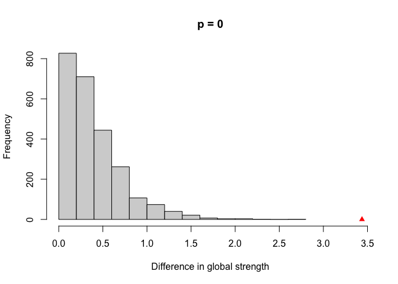

```r
library(NetworkComparisonTest)
plot_NCT(nct.results, what = "strength")
```

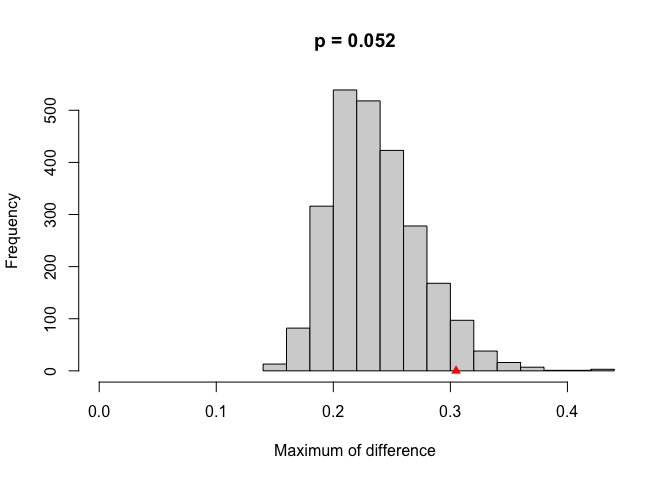

```r
plot_NCT(nct.results, what = "network")
```

We can also directly get the p-values from comparing each edge weight and centrality measure

```r
get_NCT_pvalues(nct.results, what = "edges")
```

```
##                               Var1                           Var2 p-value
## 16   AVOID.REMINDERS.OF.THE.TRAUMA    BAD.DREAMS.ABOUT.THE.TRAUMA   1.000
## 31   AVOID.REMINDERS.OF.THE.TRAUMA DISTANT.OR.CUT.OFF.FROM.PEOPLE   1.000
## 32     BAD.DREAMS.ABOUT.THE.TRAUMA DISTANT.OR.CUT.OFF.FROM.PEOPLE   1.000
## 46   AVOID.REMINDERS.OF.THE.TRAUMA       FEELING.EMOTIONALLY.NUMB   1.000
## 47     BAD.DREAMS.ABOUT.THE.TRAUMA       FEELING.EMOTIONALLY.NUMB   1.000
## 48  DISTANT.OR.CUT.OFF.FROM.PEOPLE       FEELING.EMOTIONALLY.NUMB   0.922
## 61   AVOID.REMINDERS.OF.THE.TRAUMA              FEELING.IRRITABLE   1.000
## 62     BAD.DREAMS.ABOUT.THE.TRAUMA              FEELING.IRRITABLE   1.000
## 63  DISTANT.OR.CUT.OFF.FROM.PEOPLE              FEELING.IRRITABLE   0.594
## 64        FEELING.EMOTIONALLY.NUMB              FEELING.IRRITABLE   0.325
## 76   AVOID.REMINDERS.OF.THE.TRAUMA   FEELING.PLANS.WONT.COME.TRUE   1.000
## 77     BAD.DREAMS.ABOUT.THE.TRAUMA   FEELING.PLANS.WONT.COME.TRUE   1.000
## 78  DISTANT.OR.CUT.OFF.FROM.PEOPLE   FEELING.PLANS.WONT.COME.TRUE   0.508
## 79        FEELING.EMOTIONALLY.NUMB   FEELING.PLANS.WONT.COME.TRUE   0.506
```

[output cut: 91 more lines]

```r
get_NCT_pvalues(nct.results, what = "centralities")
```

```
##                                closeness betweenness strength expectedInfluence
## AVOID.REMINDERS.OF.THE.TRAUMA         NA      1.0000   0.1024            0.0964
## BAD.DREAMS.ABOUT.THE.TRAUMA           NA      1.0000   0.2308            0.1804
## DISTANT.OR.CUT.OFF.FROM.PEOPLE         0      0.0452   0.0024            0.0016
## FEELING.EMOTIONALLY.NUMB               0      0.0280   0.0304            0.0276
## FEELING.IRRITABLE                      0      1.0000   0.0272            0.0256
## FEELING.PLANS.WONT.COME.TRUE          NA      1.0000   0.0116            0.0032
## HAVING.TROUBLE.CONCENTRATING          NA      0.1076   0.0004            0.0004
## HAVING.TROUBLE.SLEEPING               NA      1.0000   0.3428            0.2264
## LESS.INTEREST.IN.ACTIVITIES            0      0.6756   0.0024            0.0024
## NOT.ABLE.TO.REMEMBER                  NA      1.0000   0.5332            0.4704
## NOT.THINKING.ABOUT.TRAUMA             NA      0.1420   0.0008            0.0008
## PHYSICAL.REACTIONS                    NA      0.1376   0.0000            0.0000
## RELIVING.THE.TRAUMA                   NA      1.0000   0.0464            0.0272
## JUMPY.STARTLED.OVER.ALERT             NA      1.0000   0.0752            0.0756
## UPSETTING.REMINDERS                   NA      0.0000   0.0000            0.0000
```

### 5. Assess the stability of patient communities using sub-sampling analysis

To assess the stability of patient communities (aka how reliable they are), we can use sub-sampling analysis. This technique takes random subsamples of patients (default is subsamples of 100%, 99%, 95%, 90%, 80%, 70%, 60%, 50%, 40%, 30%, 20%, and 10% of the original dataset) and reruns concordance network-based patient clustering on each of the subsamples.

To perform this, we can use the cluster_subsamples function, which takes 5 parameters:

- data: Original dataframe of symptom severities (formatted as required by PRONA)
- detectAlgo: The community detection algorithm to use. It should be the same as what you used when you ran get_communities. (Default: WT)
- simil_measure: The similarity measure to use. It should be the same as what you used when you ran get_communities. (Default: ARI)
- simplify_graphs: Boolean that indicates whether to simplify the graph by removing multi-edges and loops. It should be the same as what you used when you ran get_communities. (Default: TRUE)
- sampling_rates: A vector containing the percentages to subset the data by. Default is c(1, 0.99, 0.95, 0.9, 0.8, 0.7, 0.6, 0.5, 0.4, 0.3, 0.2, 0.1). If you change this, the vector must start with 1 (meaning the first subsample is 100% of the dataset) for downstream analysis to work.

```r
subsample_communities_df <- cluster_subsamples(reduced_df)
```

The output is a dataframe that contains the community designations for each patient in each of the subsampling runs:

```r
head(subsample_communities_df, 5)
```

```
##          ID community_1 community_0.99 community_0.95 community_0.9
## 1 15_000651           2              2              1             1
## 2 15_000786           1              1              2             2
## 3 15_000969           2              2              3             3
## 4 15_000989           2              2              3             3
## 5 15_001332           2              3              1             1
##   community_0.8 community_0.7 community_0.6 community_0.5 community_0.4
## 1             4             2             1             1             3
## 2             4             2             3             3            NA
## 3             4             2             1             1             4
## 4             1             3             4             4             4
## 5             3             2             1             1             3
##   community_0.3 community_0.2 community_0.1
## 1             3            NA            NA
## 2            NA            NA            NA
## 3             2             1            NA
## 4             2             1            NA
## 5             3             3             1
```

To see the distribution of patients across different communities in each subsampling run, we can use the following code. It is important to note that cluster labels do not necessarily overlap across different runs (for example, community #2 is “subsample_communities_df$community_1” does not necessarily correspond to community #2 in “subsample_communities_df$community_0.99”). Thus, you should compare the overall distribution of patients across different communities in different runs, but not the number of patients under each specific label:

```r
table(subsample_communities_df$community_1)
```

```
##
##   1   2   3
## 136 218   5
```

```r
table(subsample_communities_df$community_0.99)
```

```
##
##   1   2   3   4
##  99 124 128   4
```

```r
table(subsample_communities_df$community_0.95)
```

```
##
##   1   2   3   4   5
## 159  79  70  30   3
```

```r
table(subsample_communities_df$community_0.9)
```

```
##
##   1   2   3   4   5
## 155  80  62  24   2
```

```r
table(subsample_communities_df$community_0.8)
```

```
##
##   1   2   3   4   5
##  78  33 125  49   2
```

```r
table(subsample_communities_df$community_0.7)
```

```
##
##  1  2  3  4  5
## 49 71 56 73  2
```

```r
table(subsample_communities_df$community_0.6)
```

```
##
##   1   2   3   4   5
## 110  32  36  35   2
```

```r
table(subsample_communities_df$community_0.5)
```

```
##
##  1  2  3  4  5
## 92 29 26 30  2
```

```r
table(subsample_communities_df$community_0.4)
```

```
##
##  1  2  3  4  5
## 13 33 70 25  2
```

```r
table(subsample_communities_df$community_0.3)
```

```
##
##  1  2  3  4
##  9 36 60  2
```

```r
table(subsample_communities_df$community_0.2)
```

```
##
##  1  2  3  4  5  6
## 17 11 33  7  2  1
```

```r
table(subsample_communities_df$community_0.1)
```

```
##
##  1  2  3  4  5
## 12  4  2 15  2
```

Next, to compute the stability of each of the original clusters across all the subsampling runs, we can use the compute_cluster_stabilities and plot_cluster_stabilities functions. These functions define “stability” as how often data points that belong to the same cluster in the original data are still clustered together in the subsamples (this is also known as Prediction Strength). It is calculated by taking all the patients that belong to one of the individual clusters, finding which communities those patients have been grouped into in the new clustering iteration, and dividing the size of the largest community in the new iteration by the size of the original community.

For example, say clustering on a dataset of 1000 patients yields three communities, one of 500 patients (community 1), one of 400 (community 2), and one of 100 (community 3). We rerun clustering on a subsample of the data, and out of the 500 patients that originally belonged to community 1, 400 of them still belong to the same community, 50 belong to a different community, and 50 were randomly removed during subsampling. The “stability” of the original community 1 for this subsampling iteration is 400/500 = 0.8 (aka 80%).

To perform this analysis on each of the original clusters for each of the subsampling iterations, use the following code:

```r
stabilities_df <- compute_cluster_stabilities(subsample_communities_df)
stabilities_df
```

```
##    SamplingRate Cluster 1 Stability Cluster 2 Stability Cluster 3 Stability
## 1             1          1.00000000          1.00000000                 1.0
## 2          0.99          0.58715596          0.72794118                 0.8
## 3          0.95          0.72935780          0.52941176                 0.6
## 4           0.9          0.68348624          0.58823529                 0.4
## 5           0.8          0.57339450          0.30147059                 0.4
## 6           0.7          0.33486239          0.36029412                 0.4
## 7           0.6          0.49082569          0.25735294                 0.4
## 8           0.5          0.39908257          0.21323529                 0.4
## 9           0.4          0.32110092          0.23529412                 0.4
## 10          0.3          0.27522936          0.20588235                 0.4
## 11          0.2          0.15137615          0.07352941                 0.2
## 12          0.1          0.06880734          0.02941176                -Inf
```

To plot these results, use the plot_cluster_stabilities function:

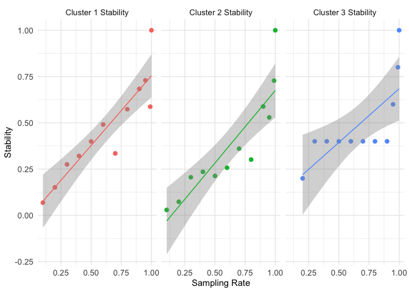

```r
plot_cluster_stabilities(stabilities_df)
```

Finally, we can use the Adjusted Rand Index (ARI) to assess the global stability of the community groupings across the different subsampling iterations. This helps us understand if the overall structure of clusters is consistent across different subsamples. We can calculate the ARI between the original clusters (represented by subsample_communities_df$community_1) and each of the subsamples using the following code:

```r
library(mclust)
adjustedRandIndex(subsample_communities_df$community_1, subsample_communities_df$community_0.99)
```

```
## [1] 0.4325011
```

```r
adjustedRandIndex(subsample_communities_df$community_1, subsample_communities_df$community_0.95)
```

```
## [1] 0.4971679
```

```r
adjustedRandIndex(subsample_communities_df$community_1, subsample_communities_df$community_0.9)
```

```
## [1] 0.5135012
```

```r
adjustedRandIndex(subsample_communities_df$community_1, subsample_communities_df$community_0.8)
```

```
## [1] 0.3745413
```

```r
adjustedRandIndex(subsample_communities_df$community_1, subsample_communities_df$community_0.7)
```

```
## [1] 0.2428197
```

```r
adjustedRandIndex(subsample_communities_df$community_1, subsample_communities_df$community_0.6)
```

```
## [1] 0.5322329
```

```r
adjustedRandIndex(subsample_communities_df$community_1, subsample_communities_df$community_0.5)
```

```
## [1] 0.4751524
```

```r
adjustedRandIndex(subsample_communities_df$community_1, subsample_communities_df$community_0.4)
```

```
## [1] 0.5615193
```

```r
adjustedRandIndex(subsample_communities_df$community_1, subsample_communities_df$community_0.3)
```

```
## [1] 0.664666
```

```r
adjustedRandIndex(subsample_communities_df$community_1, subsample_communities_df$community_0.2)
```

```
## [1] 0.4221146
```

```r
adjustedRandIndex(subsample_communities_df$community_1, subsample_communities_df$community_0.1)
```

```
## [1] 0.3372875
```

Although ARI is a helpful metric, it can be disproportionately skewed if there are specific clusters that are particularly unstable, even if the other clusters are generally stable. For this reason, we generally prefer the above analysis of individual cluster stability over ARI calculation because it gives you more specific information on which clusters are reliable and which are not.